# Correlation Exploration: Heatmaps, scatter plots and other fun things

Florencia Zúñiga

7/10/2019

#Table of contents

1. LOADING DATA

- 1.1. Creating Vorinostat
- 1.2. Creating FC Data - Finding the Biomarkers

2. Biomarkers found using the mean vs tissue

- 2.1 Table with Biomarkers, difference beatween treated and untreated, and cell lines)
- 2.2 Heatmaps)

  ```
   + [2.2.1. Heatmap with 30 Biomarkers and 59 cell lines](#anchor7)

   + [2.2.2. Heatmap with 100 Biomarkers and 59 cell lines](#anchor8)
  ```

- 2.3. Dendrogram

  ```
   + [2.3.1. Dendrogram with 30 Biomarkers and 59 cell lines](#anchor10)

   + [2.3.2. Dendrogram with 100 Biomarkers and 59 cell lines](#anchor11)

   + [2.3.3. Comparison of dendrograms with 100 Biomarkers and 30 Biomarkers](#anchor12)
  ```

- 2.4. Correlogram and Scatter Plot for 30 Biomarkers and 59 cell lines

# 1. LOADING DATA

### Loading packages

```r
library(readr)
library(rstudioapi)
library(BBmisc)
```

```r
#Packages needed for the heatmap
library(pheatmap)
library("DESeq")
```

```
## locfit 1.5-9.1    2013-03-22
```

```
##     Welcome to 'DESeq'. For improved performance, usability and
##     functionality, please consider migrating to 'DESeq2'.
```

```r
library(dendextend)
```

```r
#Packages for the dendogram
library(ggplot2)
library(circlize)
#Packages for the correlogram
library(corrgram)
```

Reading the data

```r
Untreated <- readRDS(paste0(wd,"/data/NCI_TPW_gep_untreated.rds"))
Treated <- readRDS(paste0(wd,"/data/NCI_TPW_gep_treated.rds"))

Metadata = read.table(paste0(wd,"/data/NCI_TPW_metadata.tsv"),
                      header = TRUE, sep ="\t", stringsAsFactors = TRUE)

Sensitivity <- readRDS(paste0(wd,"/data/NegLogGI50.rds"))


Basal <- readRDS(paste0(wd,"/data/CCLE_basalexpression.rds"))
Copynumber <- readRDS(paste0(wd,"/data/CCLE_copynumber.rds"))
Mutations <- readRDS(paste0(wd,"/data/CCLE_mutations.rds"))

Metadata = read.table(paste0(wd,"/data/NCI_TPW_metadata.tsv"), header = TRUE, sep ="\t", stringsAsFactors = TRUE)

Cellline_annotation = read.table(paste0(wd,"/data/cellline_annotation.tsv"),
                                 header = TRUE, sep ="\t", stringsAsFactors = TRUE)
Drug_annotation = read.table(paste0(wd,"/data/drug_annotation.tsv"),
                             header = TRUE, sep ="\t", stringsAsFactors = TRUE)
```

Transforming the data

```r
Treated <- as.data.frame(Treated)
Untreated <- as.data.frame(Untreated)
Sensitivity<- as.data.frame(Sensitivity)
```

Preparing metadata

```
##  [1] "5-Azacytidine" "bortezomib"    "cisplatin"     "dasatinib"
##  [5] "doxorubicin"   "erlotinib"     "geldanamycin"  "gemcitibine"
##  [9] "lapatinib"     "paclitaxel"    "sirolimus"     "sorafenib"
## [13] "sunitinib"     "topotecan"     "vorinostat"
```

```
## [1] Breast   CNS      Colon    Leukemia Lung     Melanoma Ovarian  Prostate
## [9] Renal
## 9 Levels: Breast CNS Colon Leukemia Lung Melanoma Ovarian ... Renal
```

Data normalization

```r
Untreated_norm <- apply(Untreated, 2, function(x){
  (x - mean(x)) / sd(x)
 })


Treated_norm <- apply(Treated, 2, function(x){
  (x - mean(x)) / sd(x)
 })


FC <- Treated - Untreated
FC_norm <- apply(FC, 2, function(x){
  (x - mean(x)) / sd(x)
 })
```

## 1.1 Biomarkers

### (1) Creating Vorinostat

```r
#Untreated matrix
UntreatedVorinostatcolumns <- grep(pattern = "vorinostat",colnames(Untreated))

#Same with treated matrix
TreatedVorinostatcolumns <- grep(pattern = "vorinostat",colnames(Treated))

#Define Vorinostat-data:
UntreatedVorinostat <- Untreated[,UntreatedVorinostatcolumns]
TreatedVorinostat <- Treated[,TreatedVorinostatcolumns]

#fold change matrix
FC <- TreatedVorinostat - UntreatedVorinostat

#Sensitivity
vorinostat_Sensitivity_alleZeilen= grep ('vorinostat', rownames(Sensitivity))
vorinostat_Sensitivity_data= Sensitivity[vorinostat_Sensitivity_alleZeilen,]
```

### (2) Creating FC Data - Finding the Biomarkers

```r
FC <- TreatedVorinostat - UntreatedVorinostat

#We work with mean of the rows because we only want to compare the genes
FC_meanrow= rowMeans(FC)

## Sorting the data
#We work with absolute value to find the highest values,
#because we want to have the most up and down regulated genes.
FC_abs= abs(FC_meanrow)

#We sort the values to get the 100 largest values
sortedFC_abs <- sort(FC_abs, decreasing = TRUE)
sortedFC_abs <- as.matrix(sortedFC_abs)

#We select the first n for biomarkers
biomarkers_FC30 = sortedFC_abs[1:30,]
biomarkers_FC30 <- as.matrix(biomarkers_FC30)

biomarkers_FC100 = sortedFC_abs[1:100,]
biomarkers_FC100 <- as.matrix(biomarkers_FC100)

## Creating a matrix with FC values, that are both positive and negative
FC_both= cbind(FC_meanrow,FC_abs)
FC_both=as.data.frame(FC_both)

#Ordering this matrix
FC_both_sorted <- FC_both[order(FC_both$FC_abs, decreasing = TRUE),]

#FC values of biomarkers: We select the first 100 of the sorted matrix.
biomarkers_FC_values30 = FC_both_sorted[1:30,]

biomarkers_FC_values100 = FC_both_sorted[1:100,]

#Removing the absolute values
biomarkers_FC_values30 <- subset( biomarkers_FC_values30, select = -FC_abs)
biomarkers_FC_values30 = as.matrix(biomarkers_FC_values30)

biomarkers_FC_values100 <- subset( biomarkers_FC_values100, select = -FC_abs)
biomarkers_FC_values100 = as.matrix(biomarkers_FC_values100)
```

## 2. Biomarkers found using the mean vs tissue

### 2.1 Table with Biomarkers, difference beatween treated and untreated, and cell lines

### CREATING THE TABLE FOR 30 BIOMARKERS

```r
cor1_tab = FC [ which(row.names(FC) %in% rownames(biomarkers_FC_values30)), ]
```

Cleaning the names of the columns and rows: COLUMNS ONLY WITH CELL LINE + CHANGE NAME OF GENE HIST, CHANGE CELL LINES NAME’S TO TISSUES

```r
col_names_cor1 = as.data.frame(strsplit(x=colnames(cor1_tab),split="_vorinostat"))
colnames (cor1_tab) = as.data.frame (t(col_names_cor1[1,]))[,1]

row_names_cor1 = as.data.frame(strsplit(x=rownames(cor1_tab),split="///HIST"))
rownames (cor1_tab) = as.data.frame (t(row_names_cor1[1,]))[,1]

cor1_tab = as.matrix(cor1_tab)
```

This table can only be read if it is a numerical matrix, so first we check if this is true

```r
class(cor1_tab)
```

```
## [1] "matrix"
```

```r
is.numeric(cor1_tab)
```

```
## [1] TRUE
```

Now that we have the table, and we know that it is a numeric matrix, we can proceed to use it to use for the heatmap

### CREATING THE TABLE FOR 100 BIOMARKERS

```r
cor1.2_tab = FC [ which(row.names(FC) %in% rownames(biomarkers_FC_values100)), ]
```

Cleaning the names of the columns and rows: COLUMNS ONLY WITH CELL LINE + CHANGE NAME OF GENE HIST, CHANGE CELL LINES NAME’S TO TISSUES

```r
col_names_cor1.2    = as.data.frame(strsplit(x=colnames(cor1.2_tab),split="_vorinostat"))
colnames (cor1.2_tab) = as.data.frame (t(col_names_cor1.2[1,]))[,1]

row_names_cor1.2    = as.data.frame(strsplit(x=rownames(cor1.2_tab),split="///HIST"))
rownames (cor1.2_tab) = as.data.frame (t(row_names_cor1.2[1,]))[,1]

cor1.2_tab = as.matrix(cor1.2_tab)
```

This table can only be read if it is a numerical matrix, so first we check if this is true

```r
class(cor1.2_tab)
```

```
## [1] "matrix"
```

```r
is.numeric(cor1.2_tab)
```

```
## [1] TRUE
```

Now that we have the table, and we know that it is a numeric matrix, we can proceed to use it to use for the heatmap

#### 2.2.1 Heatmap with 30 Biomarkers and 59 cell lines

This is how the heatmap looks making any modifications.

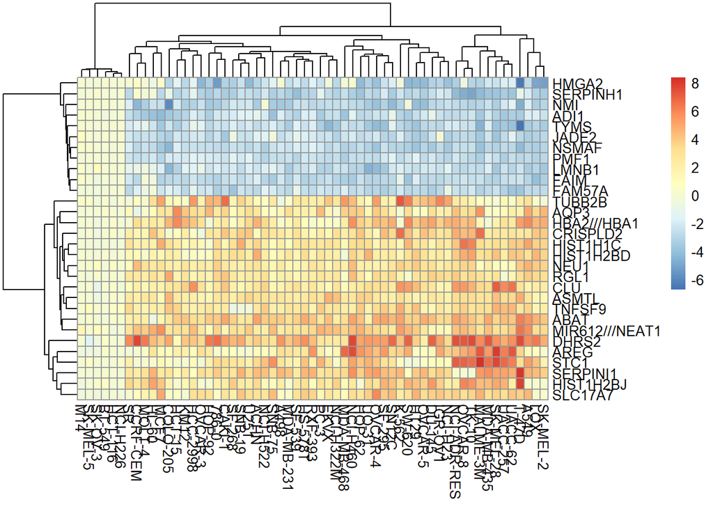

```r
pheatmap(cor1_tab)
```

#### Scaling the rows for standard normal distribution

We can visualize a pheatmap with scaled rows using the standard normal distribution. Here we use tissue names instead of cell line names.

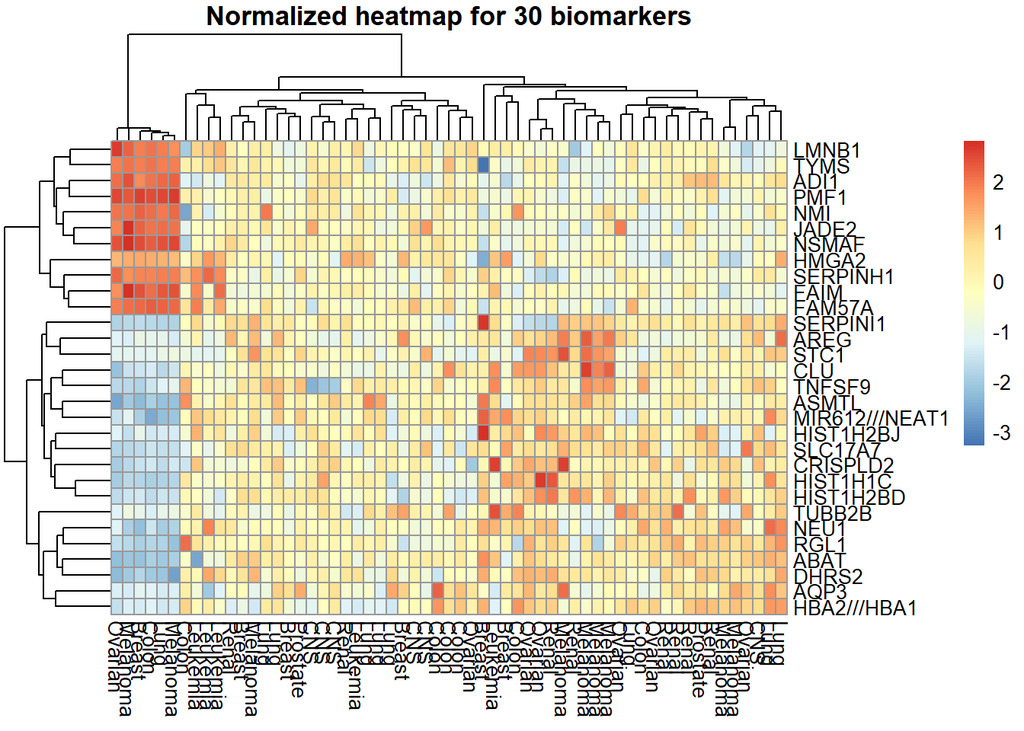

```r
cor1_tab_norm_tissue = cor1_tab_norm
colnames(cor1_tab_norm_tissue) = Metadata_V_after$tissue
pheatmap(cor1_tab_norm_tissue,
         main = "Normalized heatmap for 30 biomarkers")
```

When we apply the function for standard normal distribution, the data changes its appearence in a way in which not many conclusions can be drawn. It is for this reason that, for the rest of the analysis, the biomarkers will not be normalized using the function of the code above.

#### Ploting a dendogram and cutting the tree

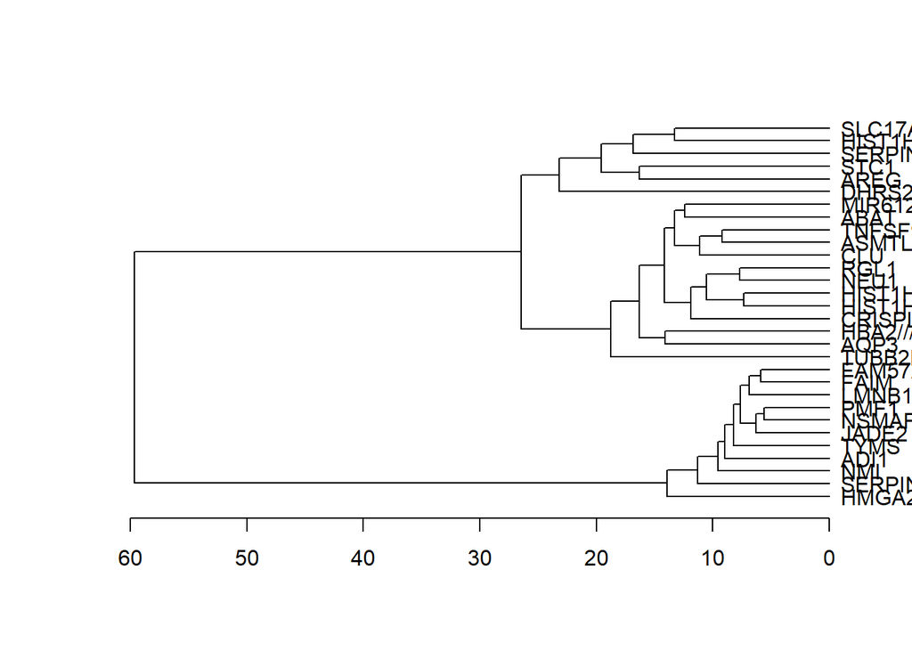

```r
cor1_hclust <- hclust(dist(cor1_tab), method = "complete")

as.dendrogram(cor1_hclust) %>%
  plot(horiz = TRUE)
```

```r
cor1_hclust_tree <- cutree(tree = as.dendrogram(cor1_hclust),
                           k = 2)
```

To which cluster do some of our genes belong?

```r
head(cor1_hclust_tree)
```

```
##  ABAT  ADI1  AQP3  AREG ASMTL   CLU
##     1     2     1     1     1     1
```

We can see that different genes belong to different clusters.

#### Creating a dataframe, needed for annotations, and adding row annotations

Tissue Annotation: Creating a table with the tissue that corresponds to each cell line

```r
tissue <- Metadata[,-c(2:5)]

row.names(tissue) <- tissue$sample
tissue <- tissue[-c(1)]


tissue = as.data.frame(tissue)
cor1_tissue <- tissue[-c(1:1579), , drop=FALSE]
cor1_tissue = as.matrix(cor1_tissue)

row_names_cor1_t    = as.data.frame(strsplit(x=rownames(cor1_tissue),split="_vorinostat"))
colnames(cor1_tissue)[colnames(cor1_tissue)=="X786.0"] <- "786.0"
rownames (cor1_tissue) = as.data.frame (t(row_names_cor1_t[1,]))[,1]

names(cor1_tissue)[names(cor1_tissue)=="V1"] <- "Tissue"

cor1_tissue = as.matrix(cor1_tissue)
```

Tissue Annotation: Creating the function for the annotation

```r
cor1_tissue_an <- data.frame(V1 = rep(c("Renal",
                                        "Lung",
                                        "Breast",
                                        "Leukemia",
                                        "Colon",
                                        "Prostate",
                                        "Ovarian",
                                        "Melanoma",
                                        "CNS"
                                        ),
                                      c(8,9,6,5,7,2,7,9,6)
                                      )
                             )

row.names(cor1_tissue_an) <- colnames(cor1_tab)
```

##### Heatmap

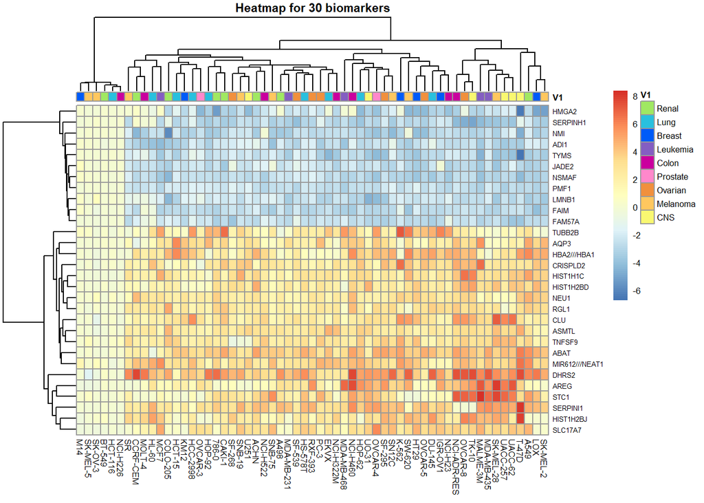

```r
cor1_colour = list(V1 = c("Renal" = "#A0E862",
                       "Lung" = "#29C0DE",
                       "Breast" = "#005BF8",
                       "Leukemia" = "#845EC2",
                       "Colon" = "#CA009E",
                       "Prostate" = "#FF88CB",
                       "Ovarian" = "#F1903D",
                       "Melanoma" = "#FFC75F",
                       "CNS" = "#F9F871"
                       )
                   )


cor1 = pheatmap(cor1_tab,
                annotation_colors = cor1_colour,
                annotation_col = cor1_tissue_an,
                fontsize = 6.5,
                fontsize_row= 5,
                fontsize_col = 6,
                gaps_col=50,
                info = TRUE,
                main = "Heatmap for 30 biomarkers"
                )
```

#####Heatmap with breaks

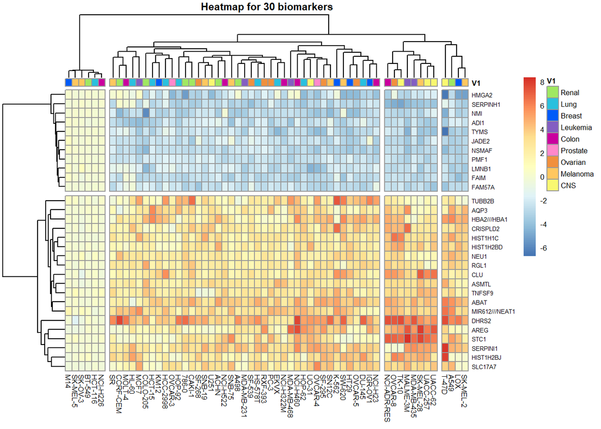

```r
pheatmap(cor1_tab,
         annotation_colors = cor1_colour,
         annotation_col = cor1_tissue_an,
         fontsize = 6.5,
         fontsize_row= 5,
         fontsize_col = 6,
         gaps_col=50,
         info = TRUE,
         cutree_rows = 2,
         cutree_cols = 4,
         main = "Heatmap for 30 biomarkers"
         )
```